# IEO_PROJECT

Pau Badia, Guillermo Palou, Javier Sanchez

30 de abril de 2019

# Analysis of TCGA RNA-seq dataset of kidney renal clear cell carcinoma

This is an R Markdown document that will show all the steps of the analysis of TCGA RNA-seq dataset of kidney renal clear cell carcinoma.

## 1. Introduction

## 2. Quality analysis

### 2.1. Data import

First, we import the dataset and store it in a `SummarizedExperiment` object, named `se`. This kind of object has genes on its rows and samples on its columns, 20,115 genes and 614 samples in our case. Both of these entities have their own associated metadata, i.e., gene symbol, lenght and GC content for genes. For samples, there are more than 500 more fields, for instance type, gender and race.

```
## class: RangedSummarizedExperiment
## dim: 20115 614
## metadata(5): experimentData annotation cancerTypeCode
##   cancerTypeDescription objectCreationDate
## assays(1): counts
## rownames(20115): 1 2 ... 102724473 103091865
## rowData names(3): symbol txlen txgc
## colnames(614): TCGA.3Z.A93Z.01A.11R.A37O.07
##   TCGA.6D.AA2E.01A.11R.A37O.07 ... TCGA.CZ.5988.11A.01R.1672.07
##   TCGA.CZ.5989.11A.01R.1672.07
## colData names(549): type bcr_patient_uuid ...
##   lymph_nodes_aortic_pos_by_ihc lymph_nodes_aortic_pos_total
```

Next, we explore the dimensions of the column data of the object, containing the samples data and see that it has 614 rows (samples) and 549 columns (metadata fields).

```
## [1] 614 549
```

```
## DataFrame with 5 rows and 5 columns
##                                  type                     bcr_patient_uuid
##                              <factor>                             <factor>
## TCGA.3Z.A93Z.01A.11R.A37O.07    tumor 2B1DEA0A-6D55-4FDD-9C1C-0D9FBE03BD78
## TCGA.6D.AA2E.01A.11R.A37O.07    tumor D3B47E53-6F40-4FC8-B5A4-CBE548A770A9
## TCGA.A3.3306.01A.01R.0864.07    tumor 9fb55e0b-43d8-40a3-8ef2-d198e6290551
## TCGA.A3.3307.01A.01R.0864.07    tumor 7ac1d6c6-9ade-49af-8794-10b5b96b2b05
## TCGA.A3.3308.01A.02R.1325.07    tumor 3cbca837-f5a7-4a87-8f02-c59eac232d5a
##                              bcr_patient_barcode form_completion_date
##                                         <factor>             <factor>
## TCGA.3Z.A93Z.01A.11R.A37O.07        TCGA-3Z-A93Z           2014-11-11
## TCGA.6D.AA2E.01A.11R.A37O.07        TCGA-6D-AA2E            2014-3-17
## TCGA.A3.3306.01A.01R.0864.07        TCGA-A3-3306            2010-8-23
## TCGA.A3.3307.01A.01R.0864.07        TCGA-A3-3307            2010-4-13
## TCGA.A3.3308.01A.02R.1325.07        TCGA-A3-3308            2010-4-12
##                              prospective_collection
##                                            <factor>
## TCGA.3Z.A93Z.01A.11R.A37O.07                    YES
## TCGA.6D.AA2E.01A.11R.A37O.07                    YES
## TCGA.A3.3306.01A.01R.0864.07                     NO
## TCGA.A3.3307.01A.01R.0864.07                     NO
## TCGA.A3.3308.01A.02R.1325.07                     NO
```

```
## DataFrame with 549 rows and 2 columns
##                                                          labelDescription
##                                                               <character>
## type                                           sample type (tumor/normal)
## bcr_patient_uuid                                         bcr patient uuid
## bcr_patient_barcode                                   bcr patient barcode
## form_completion_date                                 form completion date
## prospective_collection            tissue prospective collection indicator
## ...                                                                   ...
## lymph_nodes_pelvic_pos_total                               total pelv lnp
## lymph_nodes_aortic_examined_count                           total aor lnr
## lymph_nodes_aortic_pos_by_he                          aln pos light micro
## lymph_nodes_aortic_pos_by_ihc                                 aln pos ihc
## lymph_nodes_aortic_pos_total                                total aor-lnp
##                                         CDEID
##                                   <character>
## type                                       NA
## bcr_patient_uuid                           NA
## bcr_patient_barcode                   2673794
## form_completion_date                       NA
## prospective_collection                3088492
## ...                                       ...
## lymph_nodes_pelvic_pos_total          3151828
## lymph_nodes_aortic_examined_count     3104460
## lymph_nodes_aortic_pos_by_he          3151832
## lymph_nodes_aortic_pos_by_ihc         3151831
## lymph_nodes_aortic_pos_total          3151827
```

These metadata consists of two columns of information about the clinical variables. One called `labelDescription` contains a succint description of the variable, often not more self-explanatory than the variable name itself, and the other called ‘CDEID’ corresponds to the so-called `Common Data Element (CDE)` identifier. This identifier can be use in https://cdebrowser.nci.nih.gov to search for further information about the associated clinical variable using the `Advanced search` form and the `Public ID` attribute search.

We do the same with the gene data and observe the metadata mentioned before.

```
## [1] 20115     3
```

```
## DataFrame with 20115 rows and 3 columns
##            symbol     txlen      txgc
##       <character> <integer> <numeric>
## 1            A1BG      3322 0.5644190
## 2             A2M      4844 0.4882329
## 3            NAT1      2280 0.3942982
## 4            NAT2      1322 0.3895613
## 5        SERPINA3      3067 0.5249429
## ...           ...       ...       ...
## 20111       POTEB      1706 0.4308324
## 20112    SNORD124       104 0.4903846
## 20113   SNORD121B        81 0.4074074
## 20114      GAGE10       538 0.5055762
## 20115   BRWD1-IT2      1028 0.5924125
```

To perform quality assessment and normalization we need first to load the edgeR R/Bioconductor package and create a `DGEList’ object.

```r
library(edgeR)
dge <- DGEList(counts=assays(se)$counts, genes=mcols(se))
saveRDS(dge, file.path("results", "dge.rds"))
```

### 2.2. Within-sample normalization

Now calculate $\log_2$ CPM values of expression and put them as an additional assay element to ease their manipulation.

```r
assays(se)$logCPM <- cpm(dge, log=TRUE, prior.count=0.5)
assays(se)$logCPM[1:5, 1:5]
```

```
##    TCGA.3Z.A93Z.01A.11R.A37O.07 TCGA.6D.AA2E.01A.11R.A37O.07
## 1                      3.681094                     1.308506
## 2                     11.070451                     9.467119
## 9                     -6.544714                    -6.544714
## 10                    -6.544714                    -6.544714
## 12                     5.196098                     5.386859
##    TCGA.A3.3306.01A.01R.0864.07 TCGA.A3.3307.01A.01R.0864.07
## 1                    -0.2268151                     0.203261
## 2                     9.8676287                    11.166993
## 9                    -6.5447145                    -6.544714
## 10                   -6.5447145                    -6.544714
## 12                    4.6330031                     5.479129
##    TCGA.A3.3308.01A.02R.1325.07
## 1                     0.2380578
## 2                    11.2922910
## 9                    -6.5447145
## 10                   -6.5447145
## 12                    5.8638782
```

### 2.3. Distribution and filtering of sequencing depth

Let’s examine the sequencing depth in terms of total number of sequence read counts mapped to the genome per sample.

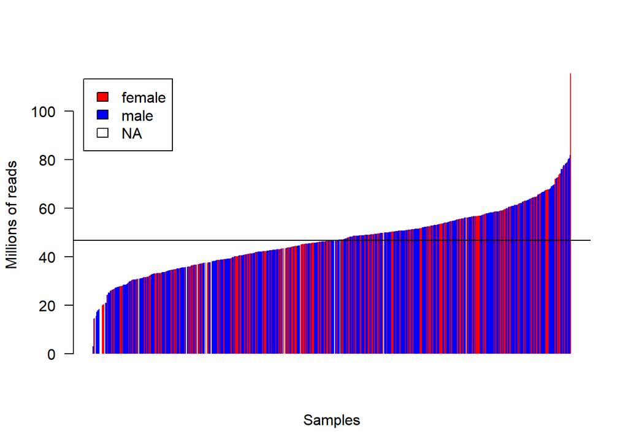

```r
ord <- order(dge$sample$lib.size)
barplot(dge$sample$lib.size[ord]/1e+06, las = 1, ylab = "Millions of reads", xlab = "Samples", col = c("red", "blue")[se$gender[ord]], border=NA, space=c(0,0))
legend("topleft", c("female", "male", "NA"), fill = c("red", "blue", "white"), inset = 0.02)
abline(h=(sum(colSums(assays(se)$counts))/1e6)/ncol(se))
```

```r
cpm_cutoff <- 21
mask <- colSums(assays(se)$counts)/1e6 > cpm_cutoff
se.filt <- se[, mask]
dge.filt <- dge[, mask]
dim(se.filt)
```

```
## [1] 20115   596
```

Store un-normalized versions of the data filtered by sample depth (cutoff of 21 CPM).

```r
saveRDS(se.filt, file.path("results", "se.filt.unnorm.rds"))
saveRDS(dge.filt, file.path("results", "dge.filt.unnorm.rds"))
```

### 2.4. Distribution of expression levels among samples

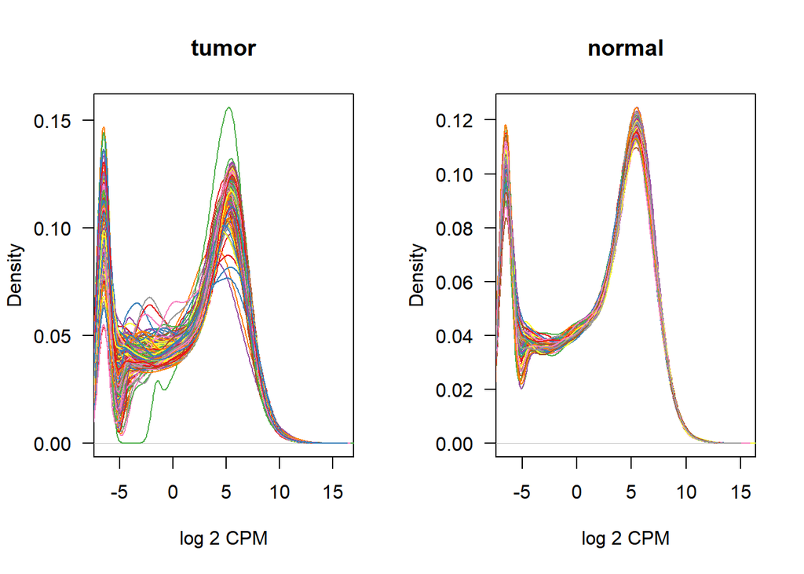

```r
library(geneplotter)
par(mfrow=c(1, 2))
multidensity(as.list(as.data.frame(assays(se[, se$type == "tumor"])$logCPM)),
             xlab="log 2 CPM", legend=NULL, main="tumor", las=1)
multidensity(as.list(as.data.frame(assays(se[, se$type == "normal"])$logCPM)),
             xlab="log 2 CPM", legend=NULL, main="normal", las=1)
```

### 2.5. Distribution and filtering of expression levels among genes

Let’s calculate now the average expression per gene through all the samples.

```r
cpm_cutoff <- round(15/min(dge.filt$samples$lib.size/1e+06), digits = 1)
cpm_cutoff
```

```
## [1] 0.6
```

```r
nsamplescutoff <- min(table(se.filt$type))
nsamplescutoff
```

```
## [1] 72
```

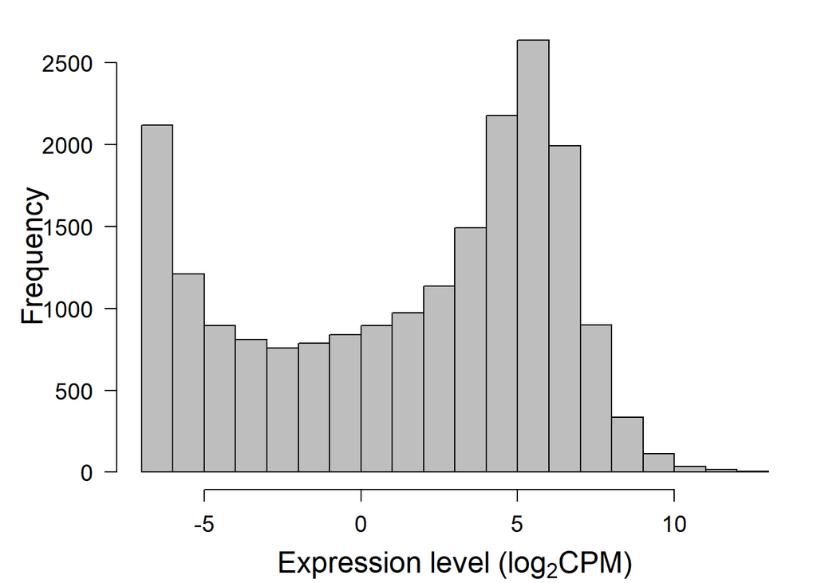

```r
mask <- rowSums(cpm(dge.filt) > cpm_cutoff) >= nsamplescutoff
se.filt2 <- se.filt[mask, ]
dge.filt2 <- dge.filt[mask, ]
avgexp <- rowMeans(assays(se.filt)$logCPM)

par(mar = c(4, 5, 1, 1))
h <- hist(avgexp, xlab = expression("Expression level (" * log[2] * "CPM)"), main = "",
    las = 1, col = "grey", cex.axis = 1.2, cex.lab = 1.5)
```

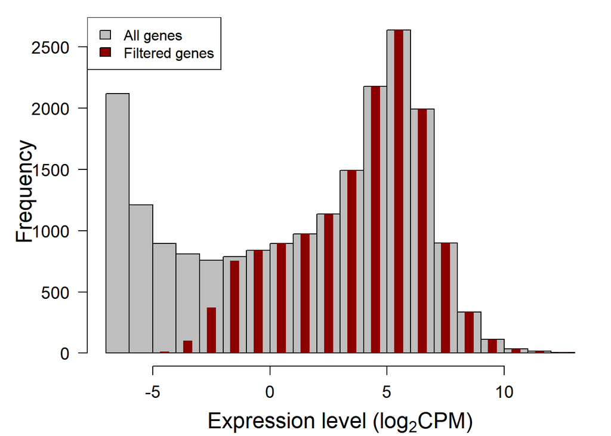

```r
par(mar = c(4, 5, 1, 1))
h <- hist(avgexp, xlab = expression("Expression level (" * log[2] * "CPM)"), main = "",
    las = 1, col = "grey", cex.axis = 1.2, cex.lab = 1.5)
x <- cut(rowMeans(assays(se.filt2)$logCPM), breaks = h$breaks)
lines(h$mids, table(x), type = "h", lwd = 10, lend = 1, col = "darkred")
legend("topleft", c("All genes", "Filtered genes"), fill = c("grey", "darkred"))
```

Store un-normalized versions of the data filtered by gene expression (cutoff of 0.6 CPM expressed in at least 72 samples).

```r
saveRDS(se.filt2, file.path("results", "se.filt2.unnorm.rds"))
saveRDS(dge.filt2, file.path("results", "dge.filt2.unnorm.rds"))
```

### 2.6. Between-sample normalization

We calculate now the normalization factors on the filtered expression data set.

```r
dge.filt2 <- calcNormFactors(dge.filt2)
dge.filt$samples$group <- se.filt$type
dge.filt2$samples$group <- se.filt2$type
table(dge.filt2$samples$group)
```

```
##
## normal  tumor
##     72    524
```

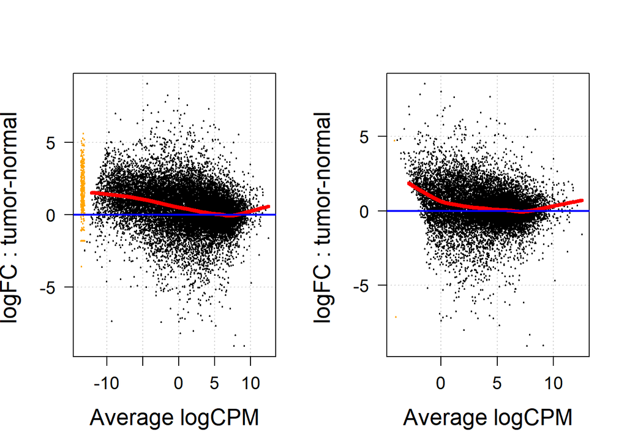

```r
par(mfrow = c(1, 2))
plotSmear(dge.filt, lowess = TRUE, las = 1, cex.lab = 1.5, cex.axis = 1.2)
abline(h = 0, col = "blue", lwd = 2)
plotSmear(dge.filt2, lowess = TRUE, las = 1, cex.lab = 1.5, cex.axis = 1.2)
abline(h = 0, col = "blue", lwd = 2)
```

### 2.7. Batch Identification

```r
tss <- substr(colnames(se.filt2), 6, 7)
center <- substr(colnames(se.filt2), 27, 28)
plate <- substr(colnames(se.filt2), 22, 25)
portionanalyte <- substr(colnames(se.filt2), 18, 20)
samplevial <- substr(colnames(se.filt2), 14, 16)

table(data.frame(TYPE=se.filt2$type, TSS=tss))
```

```
##         TSS
## TYPE      3Z  6D  A3  AK  AS  B0  B2  B4  B8  BP  CJ  CW  CZ  DV  EU  G6
##   normal   0   0   2   0   0  16   2   0   5   0  10  10  27   0   0   0
##   tumor    1   1  50  22   2 103  15   9  31 140  69  15  40  13   4   3
##         TSS
## TYPE      GK  MM  MW  T7
##   normal   0   0   0   0
##   tumor    1   3   1   1
```

```r
table(data.frame(TYPE=se.filt2$type, PLATE=plate))
```

```
##         PLATE
## TYPE     0864 1188 1277 1289 1305 1325 1334 1420 1426 1503 1541 1672 1758
##   normal    0    0    0    0    0    0    0    0    0   22   31   15    3
##   tumor    16    6   39   49   46   46   47   47   45   44   59   41    0
##         PLATE
## TYPE     1766 1858 A266 A277 A32Z A33J A37O A39I
##   normal    0    1    0    0    0    0    0    0
##   tumor     2    0   10    3    1   10   12    1
```

```r
table(data.frame(TYPE=se.filt2$type, SAMPLEVIAL=samplevial))
```

```
##         SAMPLEVIAL
## TYPE     01A 01B 05A 11A
##   normal   0   0   0  72
##   tumor  520   3   1   0
```

```r
table(data.frame(TYPE=se.filt2$type, PORTIONANALYTE=portionanalyte))
```

```
##         PORTIONANALYTE
## TYPE     01R 02R 03R 11R 12R 13R 21R
##   normal  69   3   0   0   0   0   0
##   tumor  308 115   1  94   3   1   2
```

```r
tss_list <- c("A3","B0","B2","B8","CW","CZ")
plate_list <- c(1503,1541,1672)
samplevial_list <- c("01A","11A")
portion <- "01R"
the_mask <- (substr(colnames(dge.filt),6,7) %in% tss_list & substr(colnames(dge.filt),22,25) %in% plate_list & substr(colnames(dge.filt),18,20) == portion & substr(colnames(dge.filt),14,16) %in% samplevial_list)

se.filt3 <- se.filt2[,the_mask]
dge.filt3 <- dge.filt2[,the_mask]

tss2 <- substr(colnames(se.filt3), 6, 7)
plate2 <- substr(colnames(se.filt3), 22, 25)
portionanalyte2 <- substr(colnames(se.filt3), 18, 20)
samplevial2 <- substr(colnames(se.filt3), 14, 16)

table(data.frame(TYPE=se.filt3$type, TSS=tss2))
```

```
##         TSS
## TYPE     A3 B0 B2 B8 CW CZ
##   normal  2 15  2  2  9 26
##   tumor   2 15  4  7  8 23
```

```r
table(data.frame(TYPE=se.filt3$type, PLATE=plate2))
```

```
##         PLATE
## TYPE     1503 1541 1672
##   normal   20   23   13
##   tumor    39   18    2
```

```r
table(data.frame(TYPE=se.filt3$type, SAMPLEVIAL=samplevial2))
```

```
##         SAMPLEVIAL
## TYPE     01A 11A
##   normal   0  56
##   tumor   59   0
```

```r
table(data.frame(TYPE=se.filt3$type, PORTIONANALYTE=portionanalyte2))
```

```
##         PORTIONANALYTE
## TYPE     01R
##   normal  56
##   tumor   59
```

### 2.8. Clustering according to batch effect

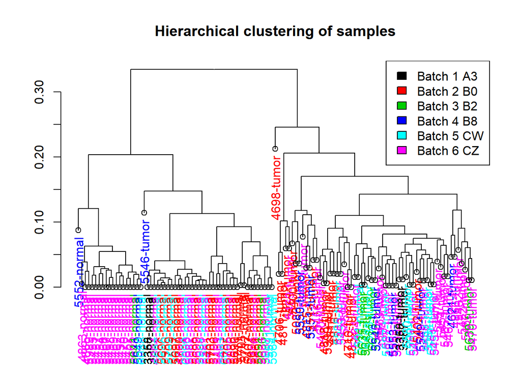

```r
logCPM <- cpm(dge.filt3, log=TRUE, prior.count=3)
d <- as.dist(1-cor(logCPM, method="spearman"))
sampleClustering <- hclust(d)
batch <- as.integer(factor(tss2))
sampleDendrogram <- as.dendrogram(sampleClustering, hang=0.1)
names(batch) <- colnames(se.filt3)
outcome <- paste(substr(colnames(se.filt3), 9, 12), as.character(se.filt3$type), sep="-")
names(outcome) <- colnames(se.filt3)
sampleDendrogram <- dendrapply(sampleDendrogram,
                               function(x, batch, labels) {
                                 if (is.leaf(x)) {
                                   attr(x, "nodePar") <- list(lab.col=as.vector(batch[attr(x, "label")]))
                                   attr(x, "label") <- as.vector(labels[attr(x, "label")])
                                 }
                                 x
                               }, batch, outcome)
plot(sampleDendrogram, main="Hierarchical clustering of samples")
legend("topright", paste("Batch", sort(unique(batch)), levels(factor(tss2))), fill=sort(unique(batch)))
```

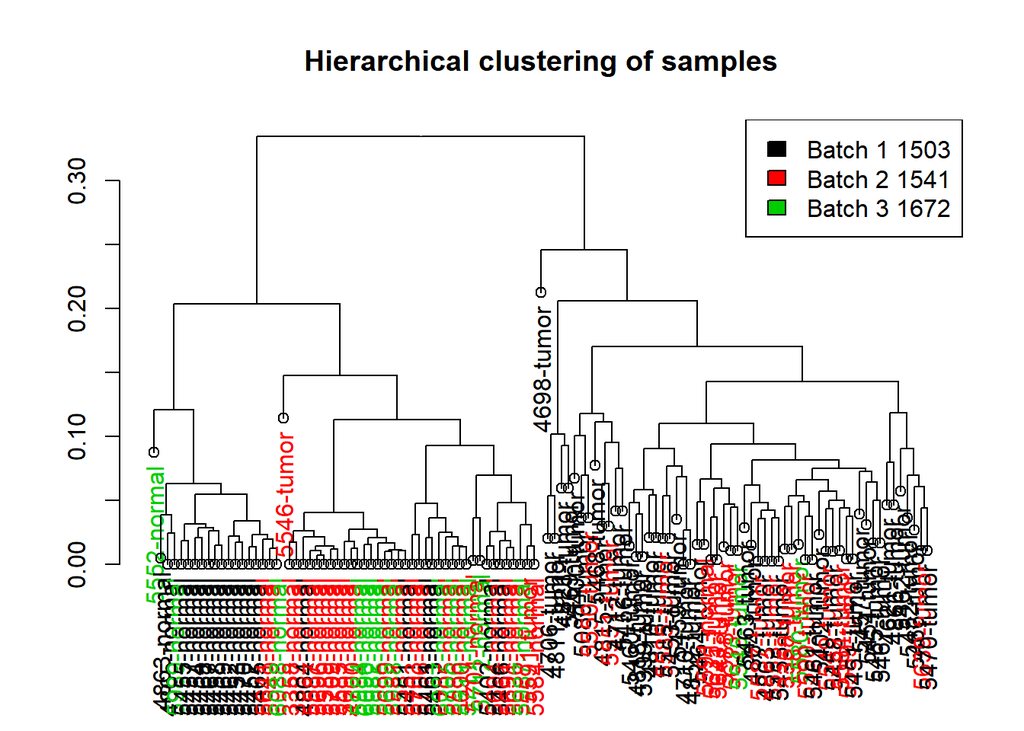

```r
batch <- as.integer(factor(plate2))
sampleDendrogram <- as.dendrogram(sampleClustering, hang=0.1)
names(batch) <- colnames(se.filt3)
outcome <- paste(substr(colnames(se.filt3), 9, 12), as.character(se.filt3$type), sep="-")
names(outcome) <- colnames(se.filt3)
sampleDendrogram <- dendrapply(sampleDendrogram,
                               function(x, batch, labels) {
                                 if (is.leaf(x)) {
                                   attr(x, "nodePar") <- list(lab.col=as.vector(batch[attr(x, "label")]))
                                   attr(x, "label") <- as.vector(labels[attr(x, "label")])
                                 }
                                 x
                               }, batch, outcome)
plot(sampleDendrogram, main="Hierarchical clustering of samples")
legend("topright", paste("Batch", sort(unique(batch)), levels(factor(plate2))), fill=sort(unique(batch)))
```

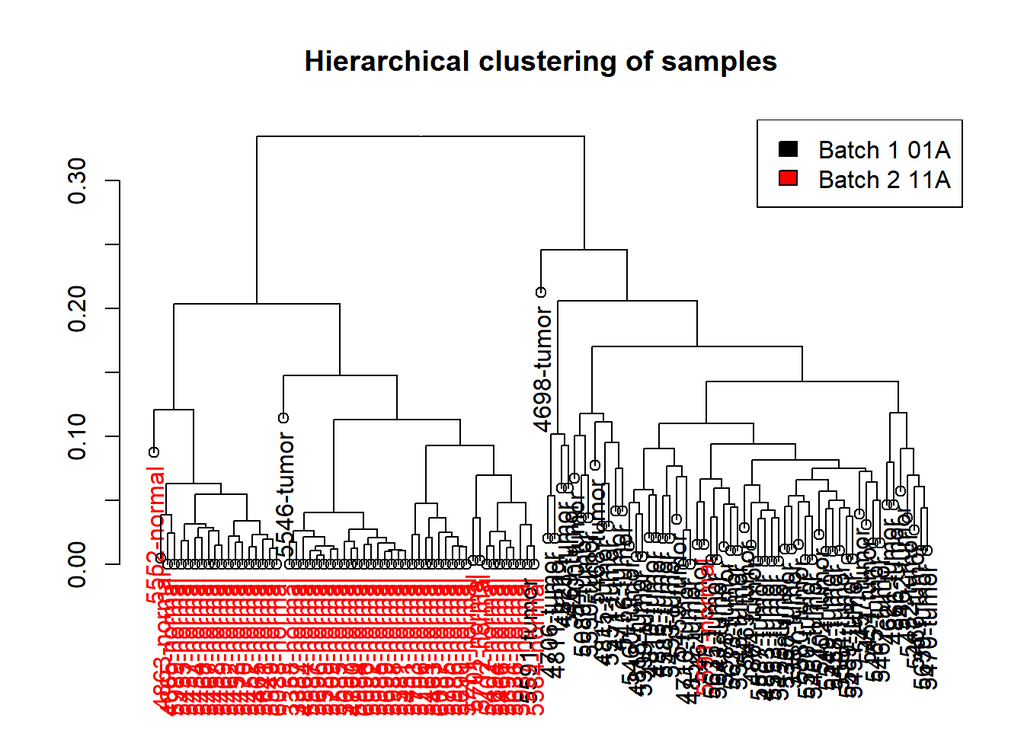

```r
batch <- as.integer(factor(samplevial2))
sampleDendrogram <- as.dendrogram(sampleClustering, hang=0.1)
names(batch) <- colnames(se.filt3)
outcome <- paste(substr(colnames(se.filt3), 9, 12), as.character(se.filt3$type), sep="-")
names(outcome) <- colnames(se.filt3)
sampleDendrogram <- dendrapply(sampleDendrogram,
                               function(x, batch, labels) {
                                 if (is.leaf(x)) {
                                   attr(x, "nodePar") <- list(lab.col=as.vector(batch[attr(x, "label")]))
                                   attr(x, "label") <- as.vector(labels[attr(x, "label")])
                                 }
                                 x
                               }, batch, outcome)
plot(sampleDendrogram, main="Hierarchical clustering of samples")
legend("topright", paste("Batch", sort(unique(batch)), levels(factor(samplevial2))), fill=sort(unique(batch)))
```

```r
se.filt4 <- se.filt3[,grep("5546|5591", colnames(se.filt3), invert=TRUE)]
dge.filt4 <- dge.filt3[,grep("5546|5591", colnames(dge.filt3), invert=TRUE)]
se.dis <- se.filt3[,grep("5546|5591", colnames(se.filt3))]
tss3 <- substr(colnames(se.filt4), 6, 7)
plate3 <- substr(colnames(se.filt4), 22, 25)
portionanalyte3 <- substr(colnames(se.filt4), 18, 20)
samplevial3 <- substr(colnames(se.filt4), 14, 16)
```

### 2.8. Clustering according to batch effect

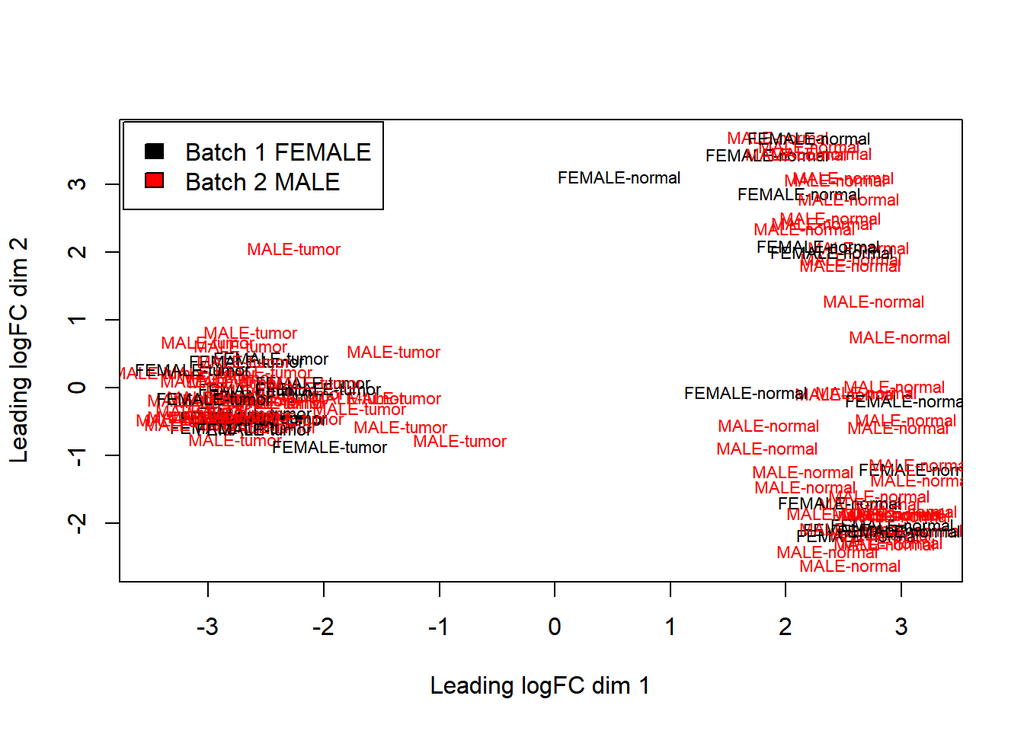

```r
colnames(dge.filt4) <- c(1:112)
colnames(se.filt4) <- c(1:112)
tumor_se <- se.filt4[,se.filt4$type == "tumor"]
tumor_dge <- dge.filt4[,se.filt4$type == "tumor"]

###GENDER
se_gender <- se.filt4[,!is.na(se.filt4$gender)]
dge_gender <- dge.filt4[,!is.na(se.filt4$gender)]
batch <- as.integer(factor(se_gender$gender))
outcome <- paste(factor(se_gender$gender), as.character(se_gender$type), sep="-")
plotMDS(dge_gender, col = batch,labels = outcome, cex = 0.7)
legend("topleft", paste("Batch", sort(unique(batch)), levels(factor(se_gender$gender))), fill=sort(unique(batch)), inset=0.005)
```

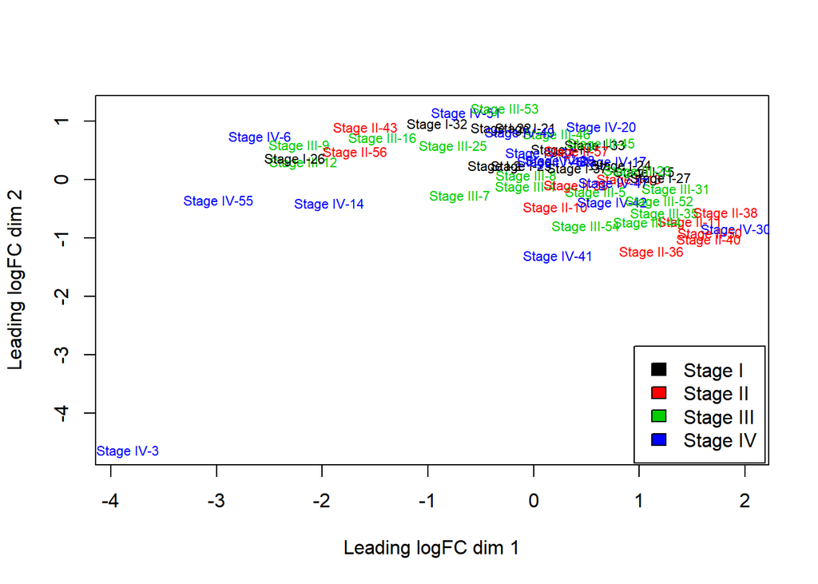

```r
###CANCER STAGE
tumor_stage_se <- tumor_se[,!is.na(tumor_se$ajcc_pathologic_tumor_stage)]
tumor_stage_dge <-tumor_dge[,!is.na(tumor_se$ajcc_pathologic_tumor_stage)]
batch <- as.integer(factor(tumor_stage_se$ajcc_pathologic_tumor_stage))
outcome <- paste(factor(tumor_stage_se$ajcc_pathologic_tumor_stage), colnames(tumor_stage_se), sep="-")
plotMDS(tumor_stage_dge, col = batch,labels = outcome, cex = 0.7)
legend("bottomright", sort(unique(batch)), levels(factor(tumor_stage_se$ajcc_pathologic_tumor_stage)), fill=sort(unique(batch)), inset=0.005)
```

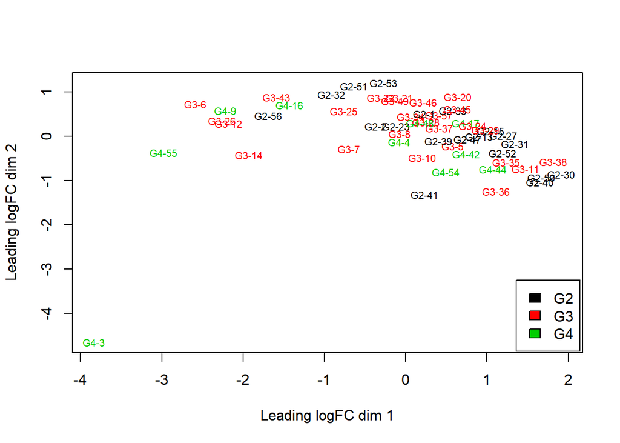

```r
###TUMOR GRADE
tumor_grade_se <- tumor_se[,!is.na(tumor_se$tumor_grade)]
tumor_grade_dge <-tumor_dge[,!is.na(tumor_se$tumor_grade)]
batch <- as.integer(factor(tumor_grade_se$tumor_grade))
outcome <- paste(factor(tumor_grade_se$tumor_grade), colnames(tumor_grade_se), sep="-")
plotMDS(tumor_grade_dge, col = batch,labels = outcome, cex = 0.7)
legend("bottomright", sort(unique(batch)), levels(factor(tumor_grade_se$tumor_grade)), fill=sort(unique(batch)), inset=0.005)
```

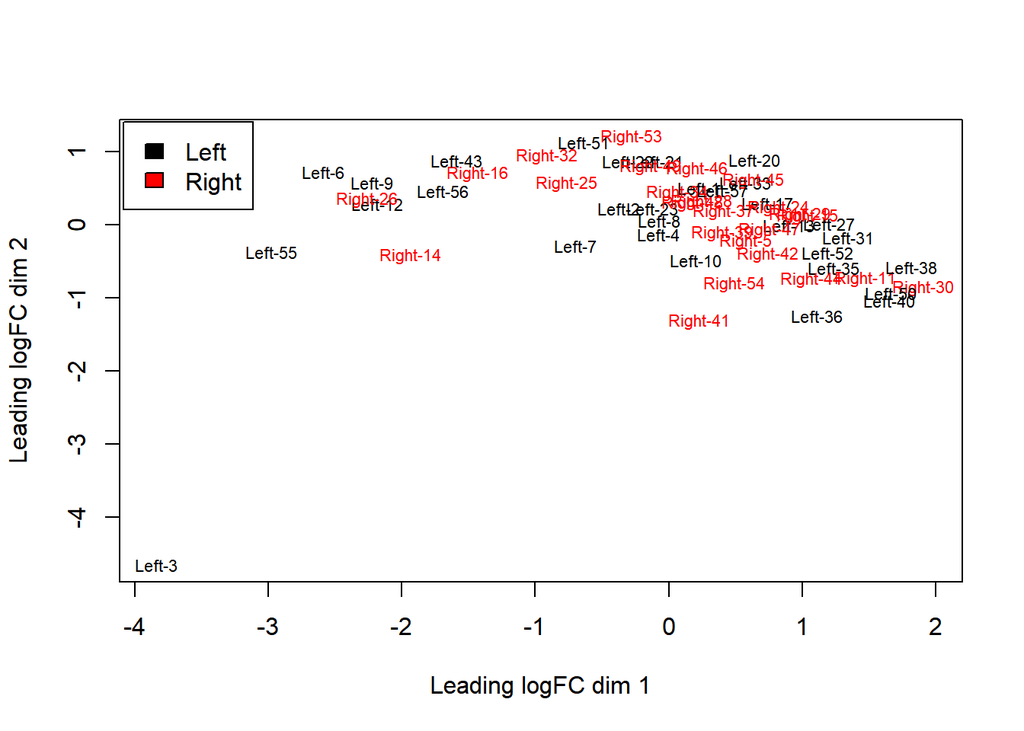

```r
###CANCER laterality
tumor_lat_se <- tumor_se[,!is.na(tumor_se$laterality)]
tumor_late_dge <-tumor_dge[,!is.na(tumor_se$laterality)]
batch <- as.integer(factor(tumor_lat_se$laterality))
outcome <- paste(factor(tumor_lat_se$laterality), colnames(tumor_lat_se), sep="-")
plotMDS(tumor_stage_dge, col = batch,labels = outcome, cex = 0.7)
legend("topleft", sort(unique(batch)), levels(factor(tumor_lat_se$laterality)), fill=sort(unique(batch)), inset=0.005)
```

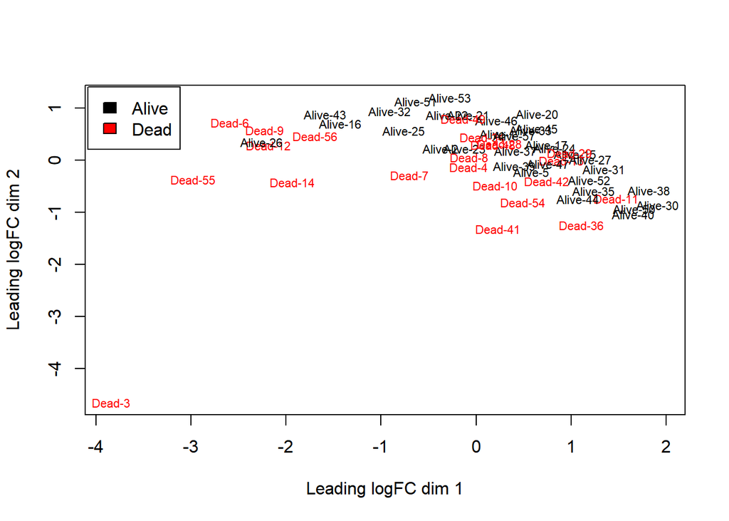

```r
###CANCER status
tumor_status_se <- tumor_se[,!is.na(tumor_se$vital_status)]
tumor_status_dge <-tumor_dge[,!is.na(tumor_se$vital_status)]
batch <- as.integer(factor(tumor_status_se$vital_status))
outcome <- paste(factor(tumor_status_se$vital_status), colnames(tumor_status_se), sep="-")
plotMDS(tumor_status_dge, col = batch,labels = outcome, cex = 0.7)
legend("topleft", sort(unique(batch)), levels(factor(tumor_status_se$vital_status)), fill=sort(unique(batch)), inset=0.005)
```

## 3. Differential expression

```r
library(sva)
mod <- model.matrix(~ se.filt4$type, colData(se.filt4))
mod0 <- model.matrix(~ 1, colData(se.filt4))
pv <- f.pvalue(assays(se.filt4)$logCPM, mod, mod0)
sum(p.adjust(pv, method="fdr")< 0.01)
```

```
## [1] 10601
```

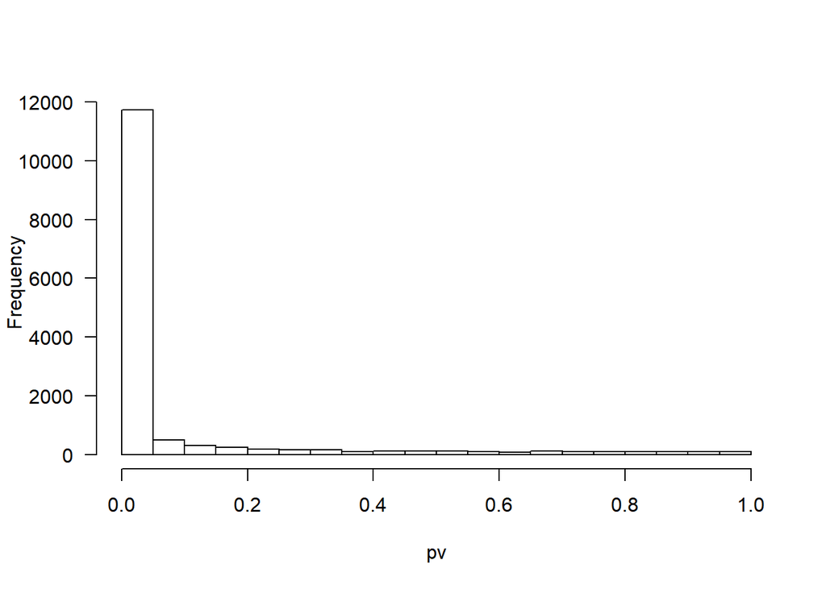

```r
hist(pv, main="",las=1)
```

Estimation of surrogate variables

```r
sv <- sva(assays(se.filt4)$logCPM, mod, mod0)
```

```
## Number of significant surrogate variables is:  18
## Iteration (out of 5 ):1  2  3  4  5
```

```r
sv$n
```

```
## [1] 18
```

```r
modsv <- cbind(mod, sv$sv)
mod0sv <- cbind(mod0, sv$sv)
pvsv <- f.pvalue(assays(se.filt4)$logCPM, modsv, mod0sv)
sum(p.adjust(pvsv,method="fdr")<0.01)
```

```
## [1] 11973
```

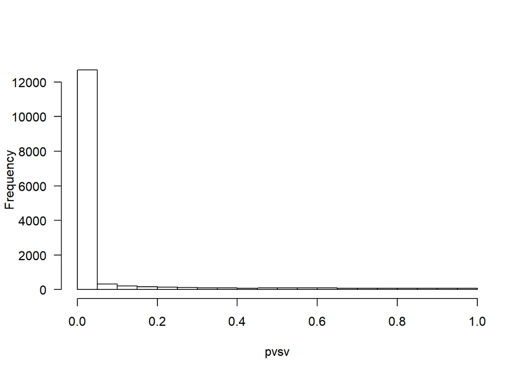

```r
hist(pvsv, main="",las=1)
```

Fold change

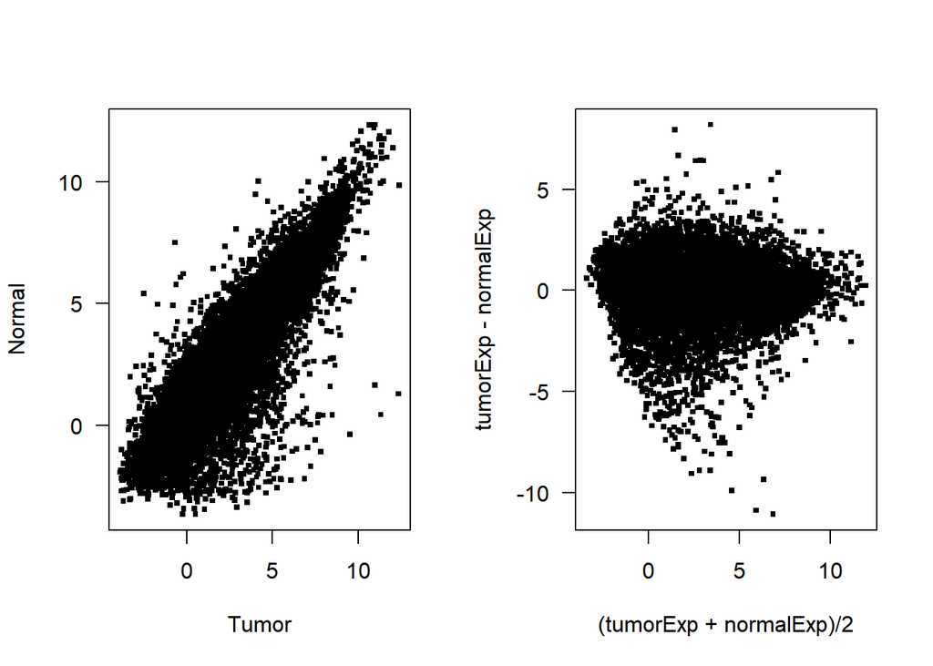

```r
tumorExp <- rowMeans(logCPM[, se.filt4$type == "tumor"])
normalExp <- rowMeans(logCPM[, se.filt4$type == "normal"])
par(mfrow = c(1, 2))
plot(normalExp, tumorExp, xlab = "Tumor", ylab = "Normal", pch = ".", cex = 4, las = 1)
plot((tumorExp + normalExp)/2, tumorExp - normalExp, pch = ".", cex = 4, las = 1)
```

```r
log2fc <- tumorExp - normalExp
ranking <- order(abs(log2fc), decreasing = TRUE)
head(data.frame(Log2FC = round(log2fc[ranking], digits = 3), FC = round(2^log2fc[ranking],
    digits = 3), `1/FC` = round(2^(-log2fc[ranking]), digits = 3), row.names = rowData(se.filt4)$symbol[ranking],
    check.names = FALSE), n = 10)
```

```
##          Log2FC      FC     1/FC
## ZNF880  -11.083   0.000 2169.764
## AQP4    -10.886   0.001 1892.719
## LAMTOR3  -9.910   0.001  962.404
## SRP54    -9.358   0.002  656.130
## CLDND2   -9.069   0.002  537.101
## GALT     -8.916   0.002  482.951
## WDFY2    -8.907   0.002  480.171
## OR2M7    -8.337   0.003  323.423
## CAB39L    8.202 294.522    0.003
## ATP6V0C  -8.105   0.004  275.302
```